# Regressão_Linear_Votos_2006_2010

Vinicius Brandão Araujo

10/10/2018

## Descrição da atividade.

Atividade desenvolvida para á disciplina de Ciência de Dados Preditiva (Período: 2018.2) ministrada pelo professor Leandro Balby. Está analise tem como objetivo fazer uma regressão Linear para Explicar a votação de Deputados e baseado nisso responder essas perguntas:

- Um modelo de regressão múltipla com todas as variáveis é plausível para explicar a variação em y (número de votos) em 2006? Mesma pergunta para 2010.
- Compare as regressões construídas para 2006 e 2010. Quais as diferenças/semelhanças percebidas?
- Todas as variáveis são úteis para os modelos de regressão? Há variáveis redudantes? Faça análises para 2006 e 2010 separadamente.
- No caso de haver variáveis pouco explicativas e/ou redudantes, construa um novo modelo sem essas variáveis e o compare ao modelo com todas as variáveis (e.g. em termos de R2 e RSE). Faça isso para 2006 e 2010 separadamente.
- Construa agora uma regressão considerando os anos 2006 e 2010 em conjunto. Que diferenças/semelhanças você percebe em relação aos modelos individuais por ano? Veja a questão 2 para sugestões que você usar para comparação.

```r
eleicoes_data <- readr::read_csv(
  here::here('data/eleicoes_2006_e_2010.csv'),
  local=readr::locale("br"),
  col_types = cols(
    ano = col_integer(),
    sequencial_candidato = col_character(),
    quantidade_doacoes = col_integer(),
    quantidade_doadores = col_integer(),
    total_receita = col_double(),
    media_receita = col_double(),
    recursos_de_outros_candidatos.comites = col_double(),
    recursos_de_pessoas_fisicas = col_double(),
    recursos_de_pessoas_juridicas = col_double(),
    recursos_proprios = col_double(),
    `recursos_de_partido_politico` = col_double(),
    quantidade_despesas = col_integer(),
    quantidade_fornecedores = col_integer(),
    total_despesa = col_double(),
    media_despesa = col_double(),
    votos = col_integer(),
    .default = col_character()))
```

## Descrição dos dados

“sequencial_candidato” :(character) id do candidato

“nome”: (character)

“uf”: (character)

“partido”: (character)

“quantidade_doacoes”: (integer)

“quantidade_doadores”: (integer) número de doadores diferentes

“total_receita”: (double) soma em R$ das doações

“media_receita”: (double) média das doações

“recursos_de_outros_candidatos/comites”: (double) quantia em R$ das doações provenientes de outros candidatos ou comite partidário

“recursos_de_pessoas_fisicas”: (double) quantia em R$ das doações provenientes de outros CPFs

“recursos_de_pessoas_juridicas”: (double) quantia em R$ das doações provenientes de outros CNPJ

“recursos_proprios”: (double) quantia em R$ das doações provenientes do próprio candidato

“recursos_de_partido_politico”: (double) quantia em R$ das doações provenientes do partido político do candidato

“votos”: (integer) variável alvo. Se refere ao número de votos na campanha de 2006 e 2010

“quantidade_despesas”: (integer)

“quantidade_fornecedores”: (integer) número de fornecedores/despesas diferentes

“total_despesa”: (double) soma em R$ das despesas de campanha

“media_despesa”: (double) média das despesas de campanha

“cargo”: (character)

“Sexo”: (character)

“grau”: (character) grau de instrução do candidato

“estado_civil”: (character)

“ocupacao”: (character) ocupação do candidato

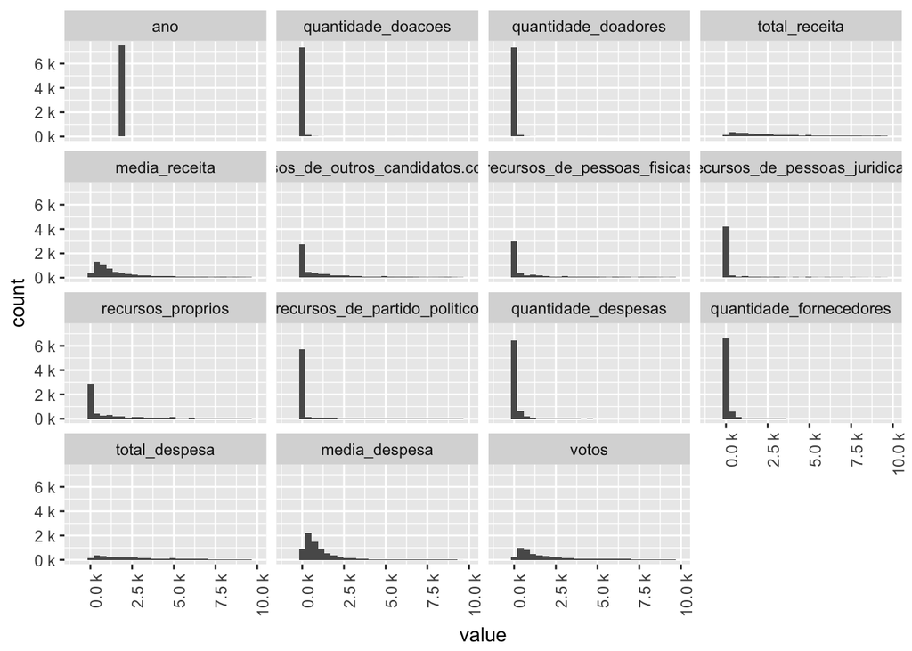

```r
remove_categorical_vars_converted = function(data) {
  return(
    data %>%
      select(-c(nome, uf, partido, cargo, sexo, grau, estado_civil, ocupacao))
  )
}

reshaped_data =
  reshape2::melt(
    eleicoes_data %>%
      remove_categorical_vars_converted)

ggplot2::ggplot(reshaped_data, aes(x = value)) +
  facet_wrap(~variable) +
  geom_histogram() +
  scale_y_continuous(label = scales::unit_format(unit = "k", scale = 1e-3))  +
  scale_x_continuous(label = scales::unit_format(unit = "k", scale = 1e-3), limits = c(-1000, 10000))  +
  theme(axis.text.x = element_text(angle = 90, hjust = 1))
```

### Pré-processando

Convertendo vars categóricas em numéricas

```r
eleicoes_data %>%
  mutate(uf = as.factor(uf),
         nome = as.factor(nome),
         sexo = as.factor(sexo),
         grau = as.factor(grau),
         nome = as.factor(nome),
         cargo = as.factor(cargo),
         partido = as.factor(partido),
         ocupacao = as.factor(ocupacao),
         estado_civil = as.factor(estado_civil),
         sequencial_candidato = as.numeric(sequencial_candidato)) -> eleicoes_data
```

## Um modelo de regressão múltipla com todas as variáveis é plausível para explicar a variação em y (número de votos) para 2006 e 2010?

### Um modelo de regressão múltipla com todas as variáveis é plausível para explicar a variação em y (número de votos) em 2006?

Para á criação destá regressão, observamos que ás variaveis categoricas nome, ano e cargo produzia um erro na regressão mesmo após a transformação, desse modeo decidir retira-las da regressão.

```r
dados_filtrado_2006 <- eleicoes_data %>%
                  filter(ano == 2006) %>%
                  select(-nome,
                         -ano,
                         -cargo) %>%
                  na.omit()
mod_2006 <- lm(votos ~ .,
          data = dados_filtrado_2006)

glance(mod_2006)
```

|  | r.squared | adj.r.squared | sigma | statistic | p.value | df | logLik | AIC | BIC | deviance | df.residual |
| --- | --- | --- | --- | --- | --- | --- | --- | --- | --- | --- | --- |
| 1 | 0.5778748 | 0.5487083 | 30549.11 | 19.813 | 0 | 223 | -40244.07 | 80936.15 | 82311.97 | 2998525247677 | 3213 |

Podemos verificar que a medida de qualidade de ajuste do modelo (Multiple R-Squared) possui um valor baixo, e também observamos que o Adj R-Squared possui um valor baixo, assim vemos que o modelo com todas as variaveis não sendo como muito plausível para a explicar a variação.

### Um modelo de regressão múltipla com todas as variáveis é plausível para explicar a variação em y (número de votos) em 2010?

Para á criação destá regressão, observamos que ás variaveis categoricas nome, ano e cargo produzia um erro na regressão mesmo após a transformação, desse modeo decidir retira-las da regressão.

```r
dados_filtrado_2010 <- eleicoes_data %>%
                  filter(ano == 2010) %>%
                  select(-nome,
                         -ano,
                         -cargo) %>%
                  na.omit()

mod_2010 <- lm(votos ~ .,
          data = dados_filtrado_2010)

glance(mod_2010)
```

|  | r.squared | adj.r.squared | sigma | statistic | p.value | df | logLik | AIC | BIC | deviance | df.residual |
| --- | --- | --- | --- | --- | --- | --- | --- | --- | --- | --- | --- |
| 1 | 0.5405273 | 0.5130385 | 34582.82 | 19.66356 | 0 | 229 | -47837.13 | 96134.26 | 97584.18 | 4557847746554 | 3811 |

Observamos que os valores de medida de qualidade de ajuste do modelo (Multiple R-Squared) possui um valor baixo, assim como o Adj R-Squared, portanto um modelo considerando todas as variaveis não é muito plausivel.

## Comparação das regressões construídas para 2006 e 2010. Quais as diferenças/semelhanças percebidas?

Para responder essa pergunta, iremos nós basear em:

- Criação do gráfico de resíduos dos modelos.
- Quais variáveis conseguem explicar melhor o número de votos?
- Comparação dos valores de R2 e RSE referente-se a cada ano.
- Analise do gráfico Normal Q-Q.

### Gráfico de resíduos dos modelos.

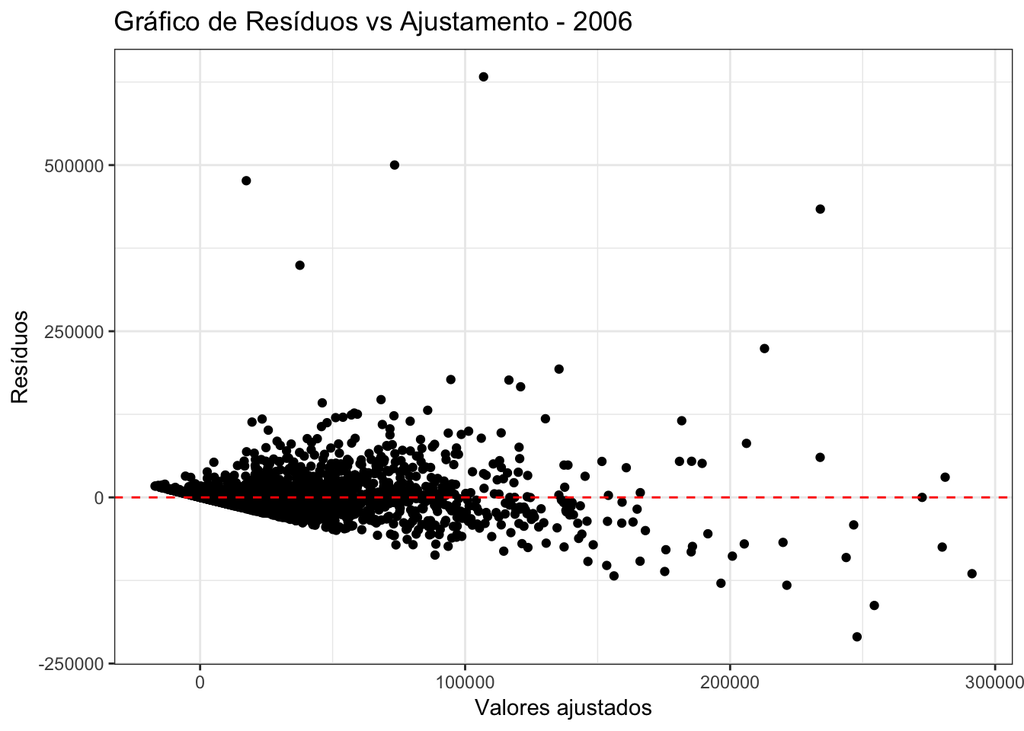

```r
require(ggplot2)
p1 = ggplot(mod_2006, aes(.fitted, .resid)) +
    geom_point()
p1 = p1 + geom_hline(yintercept=0, col="red", linetype="dashed")
p1 = p1 + xlab("Valores ajustados") + ylab("Resíduos")
p1 = p1 + ggtitle("Gráfico de Resíduos vs Ajustamento - 2006") +
    theme_bw()
p1
```

Com o gráfico acima, fica claro perceber que os erros não estão distribuidos uniformemente, tendo regiões que aglomeram uma quantidade muito alta de pontos. Além disso, a olho nú é possível notar um pequeno padrão na área inferior ao 0 que respeita a forma de uma reta. Isso pode ter acontecido pois os parâmetros passados tenham ligação entre si.

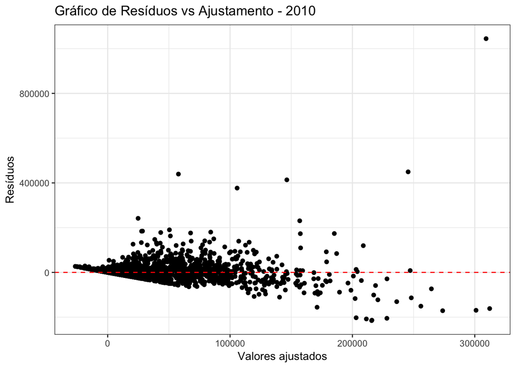

```r
require(ggplot2)
p1 = ggplot(mod_2010, aes(.fitted, .resid)) +
    geom_point()
p1 = p1 + geom_hline(yintercept=0, col="red", linetype="dashed")
p1 = p1 + xlab("Valores ajustados") + ylab("Resíduos")
p1 = p1 + ggtitle("Gráfico de Resíduos vs Ajustamento - 2010") +
    theme_bw()
p1
```

### Comparação dos valores de R2 e RSE

Summarizando o modelo obtivemos os seguintes resultados:

[output not shown]

O RSE (residual standard error) e o R² (R-squared). O primeiro fornece uma medida absoluta de falta de ajuste do modelo aos dados. Já o R² indica a proporção da variabilidade da variável alvo explicada pelo modelo. Neste caso para omodelo de 2006, por exemplo ele explica 58% dos dados, assim podemos afirmar que este modelo é razoável para explicar a quantidade de votos de um candidato. Da mesma forma o valor para o modelo de 2010 referente a 54%.

### Q-Q

> O gráfico QQ, ou quantile-quantile plot, é uma ferramenta gráfica para nos ajudar a avaliar se um conjunto de dados plausivelmente veio de alguma distribuição teórica, como Normal ou exponencial.

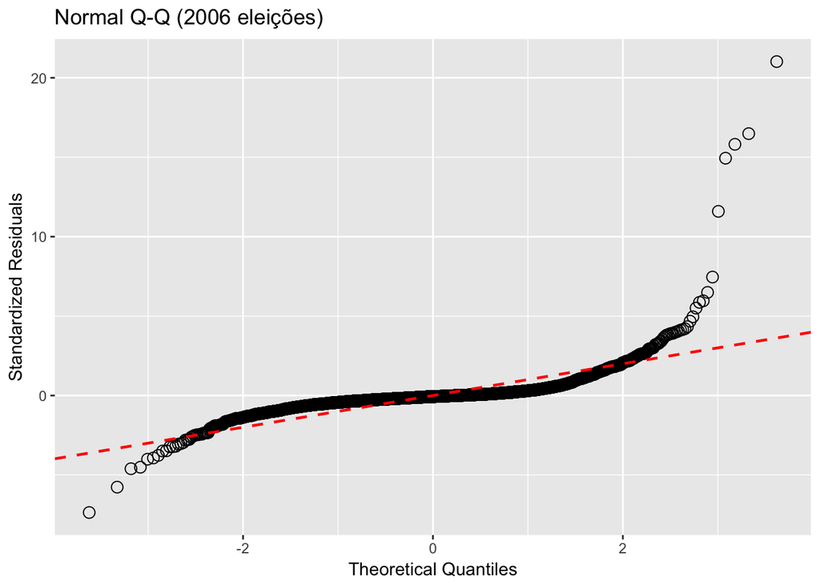

```r
mod_2006 %>%
  ggplot(aes(sample=rstandard(.))) +
  stat_qq(na.rm = TRUE,
          shape=1,size=3) +
  labs(title="Normal Q-Q (2006 eleições)",        # plot title
  x="Theoretical Quantiles",      # x-axis label
  y="Standardized Residuals") +   # y-axis label +
  geom_abline(color = "red",
              size = 0.8,
              linetype="dashed")  # dashed reference line
```

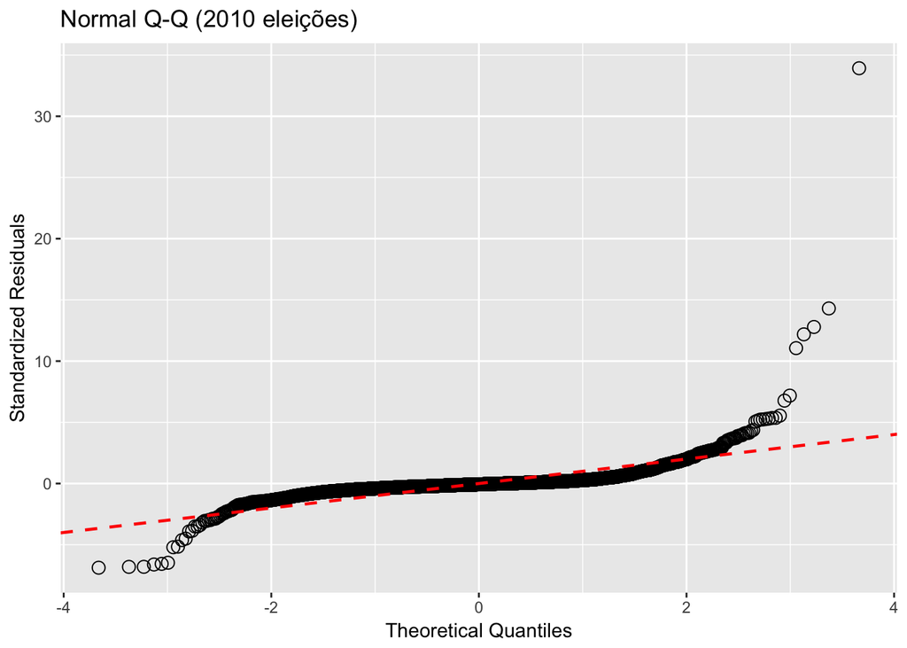

```r
mod_2010 %>%
  ggplot(aes(sample=rstandard(.))) +
  stat_qq(na.rm = TRUE,
          shape=1,size=3) +      # open circles
  labs(title="Normal Q-Q (2010 eleições)",        # plot title
  x="Theoretical Quantiles",      # x-axis label
  y="Standardized Residuals") +   # y-axis label +
  geom_abline(color = "red",
              size = 0.8,
              linetype="dashed")  # dashed reference line
```

Observamos em ambos os modelos que os pontos estão muito desajustados à linha reta, o que não é a situação ideal. Perceba que os pontos se curvam nas extremidades. Isso pode significar que nossos dados possuem mais valores extremos do que esperado caso tivessem uma distribuição normal.

## Todas as variáveis são úteis para os modelos de regressão? Há variáveis redudantes?

Para esta pergunta, foram utilizadas apenas as variáveis numéricas, já que existem muitas categorias nas variáveis categóricas, e depôs verificar a correlação. Se duas variáveis forem fortemente correlacionadas, então uma delas é redundante.

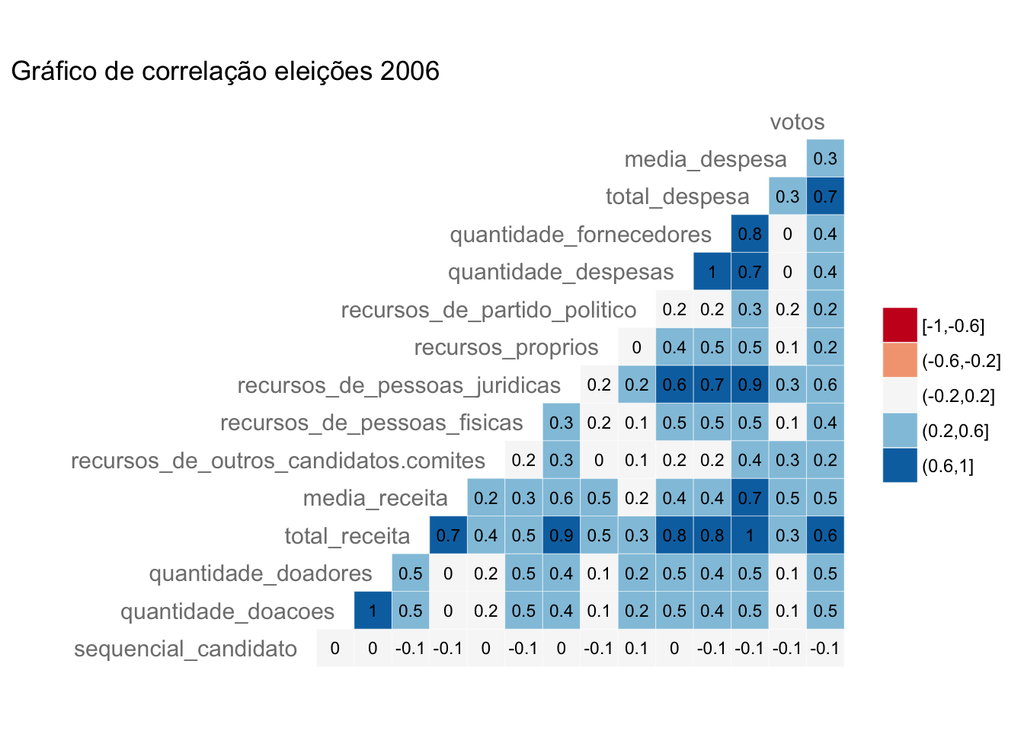

```r
eleicoes_data %>%
  filter(ano == 2006) %>%
  select(-partido,
         -uf,-nome,
         -estado_civil,
         -ocupacao,-ano,
         -cargo,-grau,-sexo) %>%
  na.omit() %>%
  ggcorr(palette = "RdBu",
         color = "grey50",
         label = TRUE, hjust = 1,
         label_size = 3, size = 4,
         nbreaks = 5, layout.exp = 7) +
  ggtitle("Gráfico de correlação eleições 2006")
```

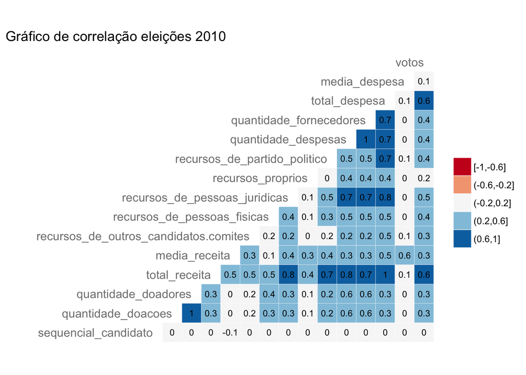

```r
eleicoes_data %>%
  filter(ano == 2010) %>%
  select(-partido,
         -uf,-nome,
         -estado_civil,
         -ocupacao,-ano,
         -cargo,-grau,-sexo) %>%
  na.omit() %>%
  ggcorr(palette = "RdBu",
         color = "grey50",
         label = TRUE, hjust = 1,
         label_size = 3, size = 4,
         nbreaks = 5, layout.exp = 7) +
  ggtitle("Gráfico de correlação eleições 2010")
```

## Novos modelos sem essas variáveis pouco explicativas e/ou redudantes.

```r
model2006 <- dados_filtrado_2006 %>%
  lm(formula = votos ~ .
     -recursos_de_pessoas_fisicas
     -recursos_de_pessoas_juridicas
     -quantidade_fornecedores
     -quantidade_doacoes
     -total_receita)

glance(model2006)
```

|  | r.squared | adj.r.squared | sigma | statistic | p.value | df | logLik | AIC | BIC | deviance | df.residual |
| --- | --- | --- | --- | --- | --- | --- | --- | --- | --- | --- | --- |
| 1 | 0.5726738 | 0.543716 | 30717.61 | 19.77618 | 0 | 219 | -40265.11 | 80970.22 | 82321.48 | 3035469991695 | 3217 |

```r
model2010 <- dados_filtrado_2010 %>%
  lm(formula = votos ~ .
     -recursos_de_pessoas_fisicas
     -recursos_de_pessoas_juridicas
     -quantidade_fornecedores
     -quantidade_doacoes
     -total_receita)

glance(model2010)
```

|  | r.squared | adj.r.squared | sigma | statistic | p.value | df | logLik | AIC | BIC | deviance | df.residual |
| --- | --- | --- | --- | --- | --- | --- | --- | --- | --- | --- | --- |
| 1 | 0.5377445 | 0.5106029 | 34669.2 | 19.81255 | 0 | 225 | -47849.33 | 96150.66 | 97575.36 | 4585452667872 | 3815 |

## Construção do modelo de 2006 e 2010 juntos.

```r
dados_filtrado_2006_2010 <- eleicoes_data %>%
  select(-partido,
         -uf,-nome,
         -estado_civil,
         -ocupacao,-ano,
         -cargo,-grau,-sexo)


mod_2006_2010 <- dados_filtrado_2006_2010 %>%
  lm(formula = votos ~ .
     -recursos_de_pessoas_fisicas
     -recursos_de_pessoas_juridicas
     -quantidade_fornecedores
     -quantidade_doacoes
     -total_receita)

summary(mod_2006_2010)
```

```
##
## Call:
## lm(formula = votos ~ . - recursos_de_pessoas_fisicas - recursos_de_pessoas_juridicas -
##     quantidade_fornecedores - quantidade_doacoes - total_receita,
##     data = .)
##
## Residuals:
##     Min      1Q  Median      3Q     Max
## -345818  -12051   -6579   -1395 1317628
##
## Coefficients:
##                                                 Estimate
## (Intercept)                           13388.914695470901
## sequencial_candidato                     -0.000000039174
## quantidade_doadores                      43.503510726761
## media_receita                             0.101303122571
## recursos_de_outros_candidatos.comites    -0.026927838756
## recursos_proprios                        -0.052133480177
## recursos_de_partido_politico             -0.046032196007
## quantidade_despesas                     -15.149906139867
## total_despesa                             0.102792371979
## media_despesa                            -0.017056617715
##                                               Std. Error t value
## (Intercept)                             611.194088197242  21.906
## sequencial_candidato                      0.000000004324  -9.059
## quantidade_doadores                       5.093191065150   8.542
## media_receita                             0.047059825328   2.153
## recursos_de_outros_candidatos.comites     0.004925759940  -5.467
## recursos_proprios                         0.003572919323 -14.591
## recursos_de_partido_politico              0.004583031428 -10.044
## quantidade_despesas                       1.769523778830  -8.562
## total_despesa                             0.002463646166  41.724
## media_despesa                             0.084742731125  -0.201
##                                                   Pr(>|t|)
## (Intercept)                           < 0.0000000000000002 ***
## sequencial_candidato                  < 0.0000000000000002 ***
## quantidade_doadores                   < 0.0000000000000002 ***
## media_receita                                       0.0314 *
## recursos_de_outros_candidatos.comites         0.0000000473 ***
## recursos_proprios                     < 0.0000000000000002 ***
## recursos_de_partido_politico          < 0.0000000000000002 ***
## quantidade_despesas                   < 0.0000000000000002 ***
## total_despesa                         < 0.0000000000000002 ***
## media_despesa                                       0.8405
## ---
## Signif. codes:  0 '***' 0.001 '**' 0.01 '*' 0.05 '.' 0.1 ' ' 1
##
## Residual standard error: 36620 on 7466 degrees of freedom
## Multiple R-squared:  0.4118, Adjusted R-squared:  0.4111
## F-statistic: 580.7 on 9 and 7466 DF,  p-value: < 0.00000000000000022
```

```r
glance(mod_2006_2010)
```

|  | r.squared | adj.r.squared | sigma | statistic | p.value | df | logLik | AIC | BIC | deviance | df.residual |
| --- | --- | --- | --- | --- | --- | --- | --- | --- | --- | --- | --- |
| 1 | 0.4117864 | 0.4110773 | 36623.92 | 580.7409 | 0 | 10 | -89164.2 | 178350.4 | 178426.5 | 10014229079883 | 7466 |

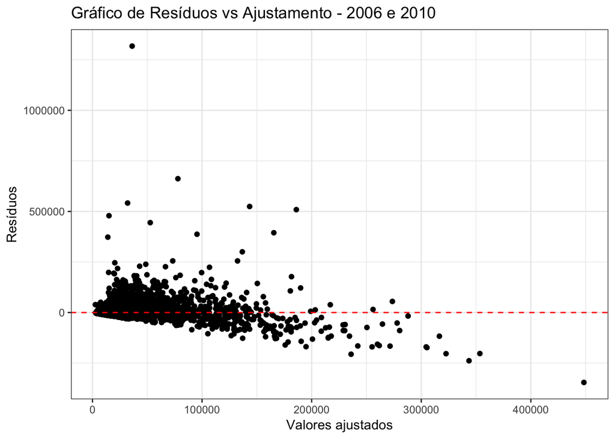

```r
p1 = ggplot(mod_2006_2010, aes(.fitted, .resid)) +
    geom_point()
p1 = p1 + geom_hline(yintercept=0, col="red", linetype="dashed")
p1 = p1 + xlab("Valores ajustados") + ylab("Resíduos")
p1 = p1 + ggtitle("Gráfico de Resíduos vs Ajustamento - 2006 e 2010") +
    theme_bw()
p1
```

Observamos no gráfico de residuos que se mantem o mesmo comportamento do modelos individuais.

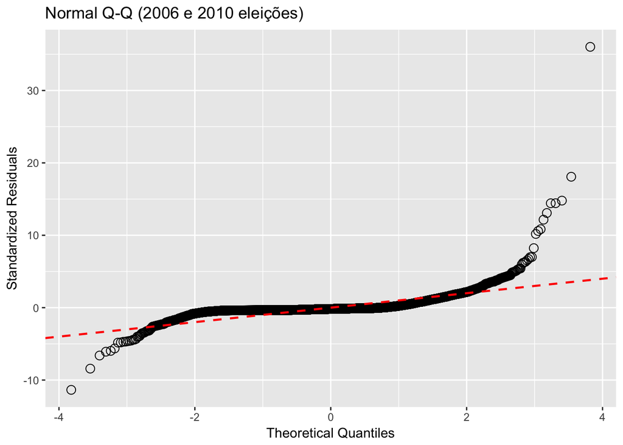

```r
mod_2006_2010 %>%
  ggplot(aes(sample=rstandard(.))) +
  stat_qq(na.rm = TRUE,
          shape=1,size=3) +      # open circles
  labs(title="Normal Q-Q (2006 e 2010 eleições)",        # plot title
  x="Theoretical Quantiles",      # x-axis label
  y="Standardized Residuals") +   # y-axis label +
  geom_abline(color = "red",
              size = 0.8,
              linetype="dashed")  # dashed reference line
```

Observamos um comportamento parecido com os modelos individuais.

**Conclusão:** Observamos que nos gráficos de resíduos e Q-Q que se assemelham aos modelos individuais, já para os valores de R2 e RSE observamos que tem uma diferença em relação aos modelos individuais, sendo assim podemos observar que o modelo considerando às duas eleições não gera uma melhoria significativa.